Ficha del establecimiento

# Escuela Boroa

RBD **9458**Pedro Aguirre CerdaEscuela o liceo

335estudiantes matriculadosCorte Agosto 2026

Mujeres50,4%169 est.

Hombres49,6%166 est.

Chilenos/as89,9%301 est.

Extranjeros/as10,1%34 est.

Actualizada al 05-10-2026

💻Ver ficha completaVersión para computador, con mapas y gráficos interactivos. Pesa varios MB: mejor ábrela con wifi.

🏛️Identificación

## Identificación del establecimiento

Los datos de contacto y las características básicas del establecimiento, tal como están registrados en el Ministerio de Educación. **Si algo está mal o falta, escríbenos** y lo corregimos en la próxima actualización.

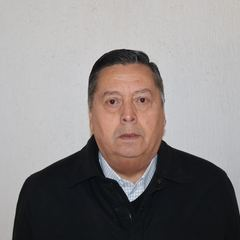

Director o directora

Pedro Alejandro Bermudez Llanten

**Nombre**

Escuela Boroa

**RBD**

9458

**Dirección**

Boroa 6079

**Comuna**

Pedro Aguirre Cerda

**Tipo**

Escuela o liceo

**Estado**

✅En funcionamiento

**Director/a**

Pedro Alejandro Bermudez Llanten

**Correo**

escuelaboroa@slepsantarosa.cl

**Teléfono**

3144760

**Sitio web**

WWW.ESCUELA-BOROA.CL

**Matrícula**

GRATUITO

**Sostenedor**

El sostenedor corresponde a una persona jurídica

**Orientación**

Orientación religiosa Laica

### Niveles que imparte

✓ 🧸 Educación Parvularia✓ 🎒 Enseñanza Básica Niños

### Vulnerabilidad del alumnado

Índice de vulnerabilidad (IVE)

84,4%

Lo calcula JUNAEB y sirve para asignar programas de apoyo.

0%100%

Este establecimientoPromedio de la comuna 85%

Prioritarios en Básica

93,7%

Estudiantes en 1ª, 2ª o 3ª prioridad.

**Un IVE más alto significa más necesidad de apoyo**, no peor calidad. Se usa para decidir a qué establecimientos llegan primero los programas de alimentación, salud y becas.

### Apoyos profesionales al aprendizaje

✓ 📚 Reforzamiento✓ 🧠 Psicólogo/a✓ 👩‍🏫 Profesor/a de educación especial✓ 🤝 Asistente social✓ 🗣️ Fonoaudiólogo/a✓ ➕ Otro: TERAPEUTA OCUPACIONAL🧩 Psicopedagogo/a🧭 Orientador/a🎓 Orientación vocacional

### Infraestructura y atención a la diversidad

✓ 📚 Biblioteca✓ 🏛️ Sala multiuso✓ 🌐 Computadores con internet✓ 🖥️ Sala de informática✓ 🏟️ Cancha deportiva✓ ➕ Otra: SALA PSICOMOTRICIDAD🔬 Laboratorio💻 Computadores📽️ Sala audiovisual🤾 Gimnasio♿ Accesibilidad NEE

✓ 🦽 Discapacidad motora✓ 🧩 Trastorno del espectro autista✓ 📖 Dificultades de aprendizaje✓ 🗣️ Trastorno específico del lenguaje✓ 🎯 Déficit atencional✓ 📊 Funcionamiento intelectual limítrofe👁️ Discapacidad visual👂 Discapacidad auditiva🧠 Discapacidad intelectual💬 Trastornos de la comunicación

Las etiquetas con ✓ son las que el establecimiento declaró en el directorio oficial; las grises no están marcadas.

### Jornada Escolar Completa (JEC)

Cursos con jornada completa

6

Cursos sin jornada completa

4

**Ver curso por curso**

| Grado | Cursos | Jornada |
| --- | --- | --- |
| 1° Básico | 1 | — Sin JEC |
| 2° Básico | 1 | — Sin JEC |
| 3° Básico | 1 | ✅ Con JEC |
| 4° Básico | 1 | ✅ Con JEC |
| 5° Básico | 1 | ✅ Con JEC |
| 6° Básico | 1 | ✅ Con JEC |
| 7° Básico | 1 | ✅ Con JEC |
| 8° Básico | 1 | ✅ Con JEC |
| Kínder | 1 | — Sin JEC |
| Pre-kínder | 1 | — Sin JEC |

Con **Jornada Escolar Completa** los estudiantes tienen más horas de clases al día y almuerzan en el establecimiento.

### Idiomas

**Inglés en Enseñanza Básica**

Básico

### Certificación ambiental (SNCAE)

El establecimiento no tiene certificación del Sistema Nacional de Certificación Ambiental de Establecimientos Educacionales (SNCAE).

### Concentración de alumnado prioritario

Concentración 2026

70,5%

▼3,03 pts

Porcentaje de estudiantes prioritarios reconocidos por el Mineduc.

0%100%

Concentración del establecimiento

Concentración 2025

73,6%

Resolución exenta

2026

Observación del Ministerio: **Mantienen ACAP**.

La **concentración de prioritarios** define cuánta Subvención Escolar Preferencial (SEP) recibe el establecimiento. Sobre 60 % da acceso a la asignación por concentración.

### Requisitos para postular

✓ 🎂 Cumplir la edad mínima✓ 📄 Certificado de nacimiento✓ 📊 Certificado de notas✓ ✍️ Firmar el proyecto educativo✓ ⚖️ Firmar el reglamento de convivencia📝 Informe de personalidad🏠 Ficha de protección social🧪 Test de intereses♿ Informe de necesidades educativas📋 Examen de ingreso👥 Entrevista con apoderados🎲 Sorteo💍 Certificado de matrimonio⛪ Certificado de bautismo⛪ Certificado de matrimonio religioso💰 Pago de postulación➕ Otro

Desde el Sistema de Admisión Escolar, los establecimientos públicos **no pueden seleccionar** por rendimiento ni por antecedentes socioeconómicos. Estos son los antecedentes administrativos que el establecimiento declara pedir.

**Equipo del SLEP que acompaña al establecimiento**

**Asesor/a territorial**

TAMARA ROA CARES

**Correo UTP**

utp.escuelaboroa@slepsantarosa.cl

**Correo Inspectoría**

inspectoria.escuelaboroa@slepsantarosa.cl

🏫Matrícula

## Matrícula y asistencia

Cuántos estudiantes tiene el establecimiento, quiénes son y cuántos días van efectivamente a clases. **La asistencia es el porcentaje de días que los estudiantes asistieron** sobre los días en que estuvieron matriculados.

Matrícula · Agosto 2026

335

▼1,8%

Variación desde el primer mes del año escolar.

1141.024

Este establecimientoPromedio del SLEP 333

Asistencia promedio

85,2%

Días asistidos sobre días matriculados.

78,5%92,2%

Este añoPromedio de años anteriores 86,4%

Cursos

10

Niveles

2

Matrícula regular

335

Estudiantes en la modalidad regular del establecimiento.

Matrícula no regular

0

Modalidades de adultos, reingreso o validación de estudios.

Matrícula mes a mes · 2026

Cuántos estudiantes había registrados al cierre de cada mes.

Asistencia mes a mes · 2026

Porcentaje de días asistidos sobre los días en que el estudiante estuvo matriculado.

Matrícula año a año

Matrícula del último mes de cada año escolar.

### Quiénes estudian acá

Por género

Hombres · 166Mujeres · 169

Por origen

Chilenos/as · 301Extranjeros/as · 34Nacionalizados/as · 0

Nacionalidades presentes

Número de estudiantes por país de nacimiento declarado.

🇨🇱 Chilena275

🌐 Otra23

🇻🇪 Venezolana14

❔ Sin información12

🇨🇴 Colombiana4

🇵🇪 Peruana3

Otros4

Pueblos originarios

Estudiantes que declaran pertenecer a un pueblo originario.

🌿 Mapuche25

🌐 Otra etnia1

### Por nivel de enseñanza

Matrícula por nivel

🧸 Educación Parvularia41

🎒 Enseñanza Básica Niños294

Asistencia por nivel

La escala va de 0 % a 100 %.

🧸 Educación Parvularia78,7%

🎒 Enseñanza Básica Niños86,1%

### Asistencia por grupo

Asistencia por género

Promedio ponderado por el número de estudiantes de cada grupo.

Hombres85,1%

Mujeres85,2%

Asistencia por origen

Chilenos/as85,0%

Extranjeros/as86,8%

Asistencia por nacionalidad

Solo los seis grupos con más estudiantes.

🇨🇱 Chilena84,7%

🌐 Otra91,1%

🇻🇪 Venezolana86,7%

❔ Sin información83,7%

🇨🇴 Colombiana69,0%

🇵🇪 Peruana93,7%

Asistencia por pueblo originario

🌿 Mapuche92,6%

🌐 Otra etnia0,0%

**Ver el detalle curso por curso (10 cursos)**

| Curso | Matrícula | Asistencia % |
| --- | --- | --- |
| Pre-kínder A | 20 | 81,7 |
| Kínder A | 21 | 76 |
| 1° Básico A | 25 | 83,8 |
| 2° Básico A | 35 | 84,1 |
| 3° Básico A | 40 | 81,9 |
| 4° Básico A | 40 | 88,8 |
| 5° Básico A | 38 | 85 |
| 6° Básico A | 40 | 85,8 |
| 7° Básico A | 40 | 89,9 |
| 8° Básico A | 36 | 88,4 |

**Ver la matrícula año a año, con su variación**

| Periodo | Matrícula | Variación | Cambio |
| --- | --- | --- | --- |
| 2026 | 335 | −8,0 | −2,3% |
| 2025 | 343 | −9,0 | −2,6% |
| 2024 | 352 | −16,0 | −4,3% |
| 2023 | 368 | −16,0 | −4,2% |
| 2022 | 384 | −4,0 | −1,0% |
| 2019 | 388 | +15,0 | +4,0% |
| 2018 | 373 | +62,0 | +19,9% |
| 2017 | 311 | −9,0 | −2,8% |
| 2016 | 320 | — | — |

**Ver la asistencia año a año, con su variación**

| Periodo | Asistencia | Variación | Cambio |
| --- | --- | --- | --- |
| 2026 | 85,2% | −2,4 pts | −2,7% |
| 2025 | 87,6% | +8,1 pts | +10,2% |
| 2024 | 79,5% | −0,1 pts | −0,1% |
| 2023 | 79,6% | −7,9 pts | −9,0% |
| 2022 | 87,5% | −3,8 pts | −4,2% |
| 2019 | 91,3% | +3,6 pts | +4,1% |
| 2018 | 87,7% | −2,6 pts | −2,9% |
| 2017 | 90,3% | +2,3 pts | +2,6% |
| 2016 | 88,0% | — | — |

La matrícula se cuenta al cierre de cada mes, así que los cambios durante el año reflejan traslados y retiros. Corte usado: **Agosto 2026**.

🤝Vida escolar

## Vida escolar y comunidad

Qué actividades ofrece el establecimiento fuera de las clases, cómo se organiza con las familias y quiénes representan a la comunidad. **Las etiquetas con ✓ son las que el establecimiento declaró** en el directorio oficial del Ministerio; las grises no están marcadas.

### Talleres y actividades para estudiantes

✓ 🤝 Convivencia✓ 🚫 Prevención drogas✓ ❤️ Educación sexual✓ 🌱 Medio ambiente✓ 🌟 Vida sana🧭 Orientación🫂 Acción social✝️ Pastoral➕ Otra

Actividades de formación: orientación, convivencia, prevención y vida sana.

✓ 🎭 Teatro✓ 🎵 Música✓ ➕ Otro: DEBATE, PERIODISMO ESCOLAR📚 Literatura✂️ Manualidades🩰 Danza o ballet🎨 Artes plásticas💻 Taller TIC🎓 Preuniversitario

Talleres de arte, cultura y tecnología fuera del horario de clases.

✓ 🥅 Baby fútbol✓ 🏐 Vóleibol⚽ Fútbol🏃 Atletismo🏀 Básquetbol🏊 Natación🤸 Gimnasia🎾 Tenis🏓 Tenis de mesa♟️ Ajedrez➕ Otro

Disciplinas deportivas que ofrece el establecimiento.

### Trabajo con las familias

✓ 👪 Talleres de formación✓ 🎉 Actividades de integración📈 Perfeccionamiento➕ Otra

✓ 🌐 Web y redes sociales✓ 🗣️ Consejo escolar✓ 📄 Reuniones generales✓ 👥 Entrevistas individuales📒 Libreta de comunicaciones➕ Otro

Por dónde el establecimiento se comunica con apoderados y apoderadas.

### Organizaciones de la comunidad

**Centro de Padres**

Constituido

**Personalidad jurídica**

En tramite

**Última elección de directiva**

**Centro de Estudiantes**

—

**Representante del sostenedor en el Consejo Escolar**

Osman Yeomans Jiménez

**Acompañamiento del Consejo Escolar**

Osman Yeomans Jiménez

Para contactar al centro de padres o al centro de estudiantes, escribe al establecimiento: sus datos están más arriba.

El **Consejo Escolar** es la instancia donde se juntan dirección, docentes, asistentes, apoderados y estudiantes para conversar sobre la marcha del establecimiento.

### Normativa y conectividad

**Uso de uniforme**

Uniforme propio del establecimiento

**Tipo de conexión**

Fibra óptica

**Velocidad de internet**

Alta velocidad

🧭Gestión

## Instrumentos de gestión: PEI y PME

El **PEI** dice quién quiere ser el establecimiento: su misión, su visión y sus sellos. El **PME** dice qué va a hacer este año para lograrlo, con responsables y presupuesto. Son los dos documentos que ordenan el trabajo.

### Proyecto Educativo Institucional (PEI)

**Misión**

Somos una comunidad educativa que potencia la neurodiversidad, a través de la gestión de los talentos y las competencias académicas, sociales, emocionales, artísticas, deportivas y culturales. Promoviendo la formación integral de los estudiantes, en conjunto con la familia para una sociedad diversa, democrática y participativa, orientando a la comunidad educativa Boroina a los desafíos para el siglo XXI, resaltando aspectos del autoconocimiento que le permitan vivir y coexistir en un entorno de excelencia educativa e innovación

**Visión**

Ser un referente en la formación integral de los estudiantes, destacando en la comunidad educativa la neurodiversidad, la gestión de los talentos y las competencias para el siglo XXI

### Énfasis declarados, en orden de prioridad

**1º**

Excelencia académica

**2º**

Desarrollo integral

**3º**

Medioambiental

### Documentos oficiales

[📘Proyecto Educativo](https://wwwfs.mineduc.cl/Archivos/infoescuelas/documentos/9458/ProyectoEducativo9458.pdf)[⚖️Reglamento de Convivencia](https://wwwfs.mineduc.cl/Archivos/infoescuelas/documentos/9458/ReglamentodeConvivencia9458.pdf)[📊Reglamento de Evaluación](https://wwwfs.mineduc.cl/Archivos/infoescuelas/documentos/9458/ReglamentoDeEvaluacion9458.pdf)

### Plan de Mejoramiento Educativo (PME)

Acciones comprometidas

25

Inversión total del plan

$ 184.403.658

Dimensiones cubiertas

4

Acciones por dimensión

Las cuatro dimensiones del PME: gestión pedagógica, liderazgo, convivencia y recursos.

Gestión Pedagógica9

Convivencia Escolar6

Gestión de Recursos6

Liderazgo4

Quién lidera las acciones

Los cinco responsables con más acciones a cargo.

Jefe técnico12

Director5

Encargado de convivencia4

Equipo de gestión2

Director - UTP1

De dónde sale el financiamiento

Monto comprometido por fuente de recursos.

sep$ 184.003.658

pie$ 400.000

**Ver las 25 acciones del plan**

| Acción | Dimensión | Responsable | Monto |
| --- | --- | --- | --- |
| Fortalecimiento del apoyo a los estudiantes | Gestión Pedagógica | Jefe técnico | $ 1.000.000 |
| Implementación de un sistema integral de evaluación y seguimiento del aprendizaje | Gestión Pedagógica | Jefe técnico | $ 200.000 |
| Acompañamiento docente | Gestión Pedagógica | Jefe técnico | $ 0 |
| Asesoría técnica y actividad de formación, información y orientación para las comunidades educativas | Gestión Pedagógica | Director | $ 200.000 |
| Potenciando las Experiencias de Aprendizaje a través de Salidas e Intervenciones Pedagógicas | Gestión Pedagógica | Jefe técnico | $ 1.899.004 |
| Programa de Desarrollo de los Estudiantes a través de Talleres Extraprogramáticos | Gestión Pedagógica | Jefe técnico | $ 1.000.000 |
| Extensión horaria para niveles sin JEC | Gestión Pedagógica | Jefe técnico | $ 0 |
| Plan de transición educativa (Decreto 373) | Gestión Pedagógica | Jefe técnico | $ 0 |
| Fortaleciendo las matemáticas | Gestión Pedagógica | Jefe técnico | $ 290.479 |
| Implementación de Estrategias de Difusión y Apropiación del PEI. | Liderazgo | Director | $ 500.000 |
| Servicio de plataforma educativa | Liderazgo | Jefe técnico | $ 2.267.189 |
| Programa de Reconocimiento y Cultura de Altas Expectativas | Liderazgo | Equipo de gestión | $ 2.000.000 |
| Contratación de Profesionales para fortalecer la gestión de soporte para los procesos educativos | Liderazgo | Sostenedor | $ 15.084.950 |
| Fortalecimiento del Vínculo Escuela-Familia a través de Entrevistas y Espacios de Diálogo | Convivencia Escolar | Equipo de gestión | $ 200.000 |
| Fortalecimiento de la Cultura de Convivencia y Comunicación Escolar | Convivencia Escolar | Encargado de convivencia | $ 200.000 |
| Implementación de un Sistema de Acompañamiento y Permanencia Escolar | Convivencia Escolar | Encargado de convivencia | $ 1.000.000 |
| Implementación de un Sistema de Apoyo Psicoeducativo | Convivencia Escolar | Encargado de convivencia | $ 200.000 |
| Servicio de transporte escolar para salidas pedagógicas y/o actividades extraescolares | Convivencia Escolar | Director - UTP | $ 5.000.000 |
| Espacios seguros y entretenidos | Convivencia Escolar | Encargado de convivencia | $ 2.346.079 |
| Optimización y Dinamización del Uso de Recursos Educativos CRA y Enlaces | Gestión de Recursos | Jefe técnico | $ 1.006.352 |
| Fortalecimiento del Equipo Multidisciplinario para una Educación Integral | Gestión de Recursos | Jefe técnico | $ 143.307.029 |
| Optimización y Modernización de Recursos Tecnológicos para el Aprendizaje | Gestión de Recursos | Jefe técnico | $ 2.409.123 |
| Servicio de equipo multicopiador para el apoyo pedagógico | Gestión de Recursos | Director | $ 2.417.989 |
| Contratación de Profesionales para el apoyo a estudiantes con NEE y TEA | Gestión de Recursos | Director | $ 0 |
| Adquisición de material escolar para el apoyo al aprendizaje | Gestión de Recursos | Director | $ 1.875.464 |

**Ver plazos y estado de ejecución de cada acción**

| Acción | Inicio | Término | Nivel de ejecución |
| --- | --- | --- | --- |
| Fortalecimiento del apoyo a los estudiantes | 08/3/2025 | 21/12/2025 | Implementación avanzada (75% a 99%) |
| Implementación de un sistema integral de evaluación y seguimiento del aprendizaje | 19/4/2025 | 21/12/2025 | Implementación avanzada (75% a 99%) |
| Acompañamiento docente | 19/4/2025 | 19/12/2025 | Implementación avanzada (75% a 99%) |
| Asesoría técnica y actividad de formación, información y orientación para las comunidades educativas | 03/3/2025 | 31/12/2025 | Implementado de manera adecuada (50% a 74%) |
| Potenciando las Experiencias de Aprendizaje a través de Salidas e Intervenciones Pedagógicas | 03/3/2025 | 19/12/2025 | Implementación avanzada (75% a 99%) |
| Programa de Desarrollo de los Estudiantes a través de Talleres Extraprogramáticos | 01/4/2025 | 20/12/2025 | Implementación avanzada (75% a 99%) |
| Extensión horaria para niveles sin JEC | 02/1/2025 | 30/12/2025 | Implementación avanzada (75% a 99%) |
| Plan de transición educativa (Decreto 373) | 03/3/2025 | 30/12/2025 | Implementación avanzada (75% a 99%) |
| Fortaleciendo las matemáticas | 07/7/2025 | 19/12/2025 | Implementación avanzada (75% a 99%) |
| Implementación de Estrategias de Difusión y Apropiación del PEI. | 19/4/2025 | 19/12/2025 | No Implementado (0%) |
| Servicio de plataforma educativa | 03/3/2025 | 31/12/2025 | No Implementado (0%) |
| Programa de Reconocimiento y Cultura de Altas Expectativas | 19/4/2025 | 19/12/2025 | No Implementado (0%) |
| Contratación de Profesionales para fortalecer la gestión de soporte para los procesos educativos | 05/3/2025 | 31/12/2025 | Implementado de manera adecuada (50% a 74%) |
| Fortalecimiento del Vínculo Escuela-Familia a través de Entrevistas y Espacios de Diálogo | 01/4/2025 | 18/12/2025 | Implementado de manera adecuada (50% a 74%) |
| Fortalecimiento de la Cultura de Convivencia y Comunicación Escolar | 08/3/2025 | 20/12/2025 | Implementado parcialmente (25 a 49%) |
| Implementación de un Sistema de Acompañamiento y Permanencia Escolar | 08/3/2025 | 20/12/2025 | Implementado inicialmente (1% a 24%) |
| Implementación de un Sistema de Apoyo Psicoeducativo | 06/3/2025 | 18/12/2025 | Implementado parcialmente (25 a 49%) |
| Servicio de transporte escolar para salidas pedagógicas y/o actividades extraescolares | 03/3/2025 | 30/12/2025 | Implementado inicialmente (1% a 24%) |
| Espacios seguros y entretenidos | 07/7/2025 | 19/12/2025 | No Implementado (0%) |
| Optimización y Dinamización del Uso de Recursos Educativos CRA y Enlaces | 07/3/2025 | 19/12/2025 | Implementado inicialmente (1% a 24%) |
| Fortalecimiento del Equipo Multidisciplinario para una Educación Integral | 07/3/2025 | 19/12/2025 | Implementado (100%) |
| Optimización y Modernización de Recursos Tecnológicos para el Aprendizaje | 06/3/2025 | 18/12/2025 | Implementado inicialmente (1% a 24%) |
| Servicio de equipo multicopiador para el apoyo pedagógico | 03/3/2025 | 30/12/2025 | Implementado inicialmente (1% a 24%) |
| Contratación de Profesionales para el apoyo a estudiantes con NEE y TEA | 03/3/2025 | 31/12/2025 | No Implementado (0%) |
| Adquisición de material escolar para el apoyo al aprendizaje | 03/3/2025 | 31/12/2025 | No Implementado (0%) |

**Ver estrategia, programa y medios de verificación**

| Acción | Estrategia | Programa asociado | Medios de verificación |
| --- | --- | --- | --- |
| Fortalecimiento del apoyo a los estudiantes | Monitoreo del Plan de Apoyo a la Inclusión, que incorpore herramientas de evaluación, para garantizar una respuesta pedagógica flexible y diferenciada. | PIE | -Reportes de progreso individuales -Actas de coordinación entre el equipo PIE y docentes de aula -Encuestas de percepción y análisis a estudiantes con NEE |
| Implementación de un sistema integral de evaluación y seguimiento del aprendizaje | Monitoreo del Plan de Apoyo a la Inclusión, que incorpore herramientas de evaluación, para garantizar una respuesta pedagógica flexible y diferenciada. | PIE | -Reglamento de Evaluación y Promoción Escolar 2025 -Encuestas de percepción y análisis a estudiantes con NEE. -Actas de coordinación entre el equipo PIE y docentes de aula. -Reportes de progreso indiv… |
| Acompañamiento docente | Monitoreo al plan de desarrollo profesional docente basado en la retroalimentación reflexiva, el aprendizaje colaborativo y la innovación pedagógica. | Ninguno | -Actas de participación docente en instancias formativas. -Registros de Observación y Retroalimentación Docente. -Encuesta de percepción del acompañamiento y análisis a docentes. -Cronograma de acompa… |
| Asesoría técnica y actividad de formación, información y orientación para las comunidades educativas | Monitoreo al plan de desarrollo profesional docente basado en la retroalimentación reflexiva, el aprendizaje colaborativo y la innovación pedagógica. | SEP | -PPT y documentos de la capacitación -Plan de Desarrollo Profesional Docente 2025. |
| Potenciando las Experiencias de Aprendizaje a través de Salidas e Intervenciones Pedagógicas | Monitoreo al plan de desarrollo profesional docente basado en la retroalimentación reflexiva, el aprendizaje colaborativo y la innovación pedagógica. | Ninguno | -Encuestas de satisfacción a estudiantes y docentes sobre las experiencias pedagógicas. -Informes de impacto y pertinencia, con evidencias de aprendizajes adquiridos. -Registros audiovisuales y cápsul… |
| Programa de Desarrollo de los Estudiantes a través de Talleres Extraprogramáticos | Monitoreo al plan de desarrollo profesional docente basado en la retroalimentación reflexiva, el aprendizaje colaborativo y la innovación pedagógica. | SEP | -Presentación anual de talleres -Plan Anual de Talleres Extraprogramáticos con objetivos y metodologías definidas. -Registro de asistencia y participación de los estudiantes en talleres. -Informes de … |
| Extensión horaria para niveles sin JEC | Monitoreo al plan de desarrollo profesional docente basado en la retroalimentación reflexiva, el aprendizaje colaborativo y la innovación pedagógica. | SEP | -Registro de asistencia -Plan de trabajo |
| Plan de transición educativa (Decreto 373) | Monitoreo al plan de desarrollo profesional docente basado en la retroalimentación reflexiva, el aprendizaje colaborativo y la innovación pedagógica. | SEP | -Plan de transición |
| Fortaleciendo las matemáticas | Monitoreo al plan de desarrollo profesional docente basado en la retroalimentación reflexiva, el aprendizaje colaborativo y la innovación pedagógica. | SEP | -Análisis cualitativo de resultados en pruebas institucionales. -Planificación de clases con uso de esta herramienta |
| Implementación de Estrategias de Difusión y Apropiación del PEI. | Ejecución de jornadas de análisis y reflexión en torno a las necesidades y proyección escolar, con participación de todos los estamentos de la comunidad educativa. | Ninguno | -Material de Difusión del PEI. -Programa y Comisiones de Organización de los Hitos Institucionales. -Evaluación del Impacto de las Actividades, con encuestas y retroalimentación. -Registros de Partici… |
| Servicio de plataforma educativa | Ejecución de jornadas de análisis y reflexión en torno a las necesidades y proyección escolar, con participación de todos los estamentos de la comunidad educativa. | SEP | -Reportes -Informe de notas -Informe uso plataforma |
| Programa de Reconocimiento y Cultura de Altas Expectativas | Ejecución de jornadas de análisis y reflexión en torno a las necesidades y proyección escolar, con participación de todos los estamentos de la comunidad educativa. | SEP | -Nómina de Destacados/as, con diplomas y reconocimientos otorgados. -Descriptores de categorías de premiación. |
| Contratación de Profesionales para fortalecer la gestión de soporte para los procesos educativos | Ejecución de jornadas de análisis y reflexión en torno a las necesidades y proyección escolar, con participación de todos los estamentos de la comunidad educativa. | SEP | -Informes de avance y ejecución -Convenio de prestación de servicios |
| Fortalecimiento del Vínculo Escuela-Familia a través de Entrevistas y Espacios de Diálogo | Fortalecimiento de la difusión del RISE/RIE en los distintos estamentos de la comunidad educativa. | SEP | -Registro sistematizado de entrevistas y reuniones. -Plan de trabajo del Centro de Padres para vinculación escuela-familia. -Actas y minutas de reuniones de apoderados. -Protocolo de entrevista a la f… |
| Fortalecimiento de la Cultura de Convivencia y Comunicación Escolar | Fortalecimiento de la difusión del RISE/RIE en los distintos estamentos de la comunidad educativa. | SEP | -Registro audiovisual y parrilla de publicaciones subidas en RR.SS. -Plan Anual de Trabajo del Equipo de Comunicaciones y su vinculación con la convivencia escolar. -Evaluación del impacto de las camp… |
| Implementación de un Sistema de Acompañamiento y Permanencia Escolar | Fortalecimiento de la difusión del RISE/RIE en los distintos estamentos de la comunidad educativa. | SEP | -Plan Anual de Intervención para la Permanencia Escolar 2025. -Registros de derivaciones, visitas domiciliarias y entrevistas con estudiantes, apoderados y docente -Informes de seguimiento con análisi… |
| Implementación de un Sistema de Apoyo Psicoeducativo | Fortalecimiento de la difusión del RISE/RIE en los distintos estamentos de la comunidad educativa. | SEP | -Plan Anual de Trabajo Psicóloga 2025. -Registro de intervenciones individuales y grupales. -Estrategias de detección temprana y protocolos de actuación. -Talleres de formación en salud mental para do… |
| Servicio de transporte escolar para salidas pedagógicas y/o actividades extraescolares | Fortalecimiento de la difusión del RISE/RIE en los distintos estamentos de la comunidad educativa. | SEP | -Formulario C -Protocolo de seguridad -Programa salidas pedagógicas |
| Espacios seguros y entretenidos | Fortalecimiento de la difusión del RISE/RIE en los distintos estamentos de la comunidad educativa. | SEP | -Reporte de la disminución de conflictos menores durante los recreos (mejor convivencia). -Encuesta de percepión positiva de estudiantes y docentes sobre los nuevos espacios |
| Optimización y Dinamización del Uso de Recursos Educativos CRA y Enlaces | Utilización activa de los recursos didácticos, tecnológicos, humanos, y de los espacios vinculados al quehacer pedagógico, tales como CRA, Sala de Enlaces y Sala Psicomotricidad. | CRA | -Informe de impacto en el aprendizaje basado en indicadores de uso y satisfacción. -Registro digital de préstamos y seguimiento de uso de recursos educativos. -Plan de gestión anual Biblioteca CRA y S… |
| Fortalecimiento del Equipo Multidisciplinario para una Educación Integral | Utilización activa de los recursos didácticos, tecnológicos, humanos, y de los espacios vinculados al quehacer pedagógico, tales como CRA, Sala de Enlaces y Sala Psicomotricidad. | SEP | -Informe de evaluación de desempeño y medición de impacto en los aprendizajes y convivencia escolar. -Ficha de solicitud de contratación SEP, con justificación basada en datos de gestión educativa. -P… |
| Optimización y Modernización de Recursos Tecnológicos para el Aprendizaje | Utilización activa de los recursos didácticos, tecnológicos, humanos, y de los espacios vinculados al quehacer pedagógico, tales como CRA, Sala de Enlaces y Sala Psicomotricidad. | SEP | -Plan de adquisición y mantenimiento de recursos tecnológicos. -Inventario actualizado de equipos y materiales tecnológicos. -Registro de uso y asignación de recursos por parte de docentes y estudiant… |
| Servicio de equipo multicopiador para el apoyo pedagógico | Utilización activa de los recursos didácticos, tecnológicos, humanos, y de los espacios vinculados al quehacer pedagógico, tales como CRA, Sala de Enlaces y Sala Psicomotricidad. | SEP | -Registro de material impreso -Contrato suministro -Informe de impresiones mensuales |
| Contratación de Profesionales para el apoyo a estudiantes con NEE y TEA | Utilización activa de los recursos didácticos, tecnológicos, humanos, y de los espacios vinculados al quehacer pedagógico, tales como CRA, Sala de Enlaces y Sala Psicomotricidad. | SEP | -Registro de asistencia -Plan de trabajo |
| Adquisición de material escolar para el apoyo al aprendizaje | Utilización activa de los recursos didácticos, tecnológicos, humanos, y de los espacios vinculados al quehacer pedagógico, tales como CRA, Sala de Enlaces y Sala Psicomotricidad. | SEP | -Facturas -Procesos de compras públicas |

**Ver la descripción completa y la justificación de cada acción**

| Acción | Qué se hace | Por qué |
| --- | --- | --- |
| Fortalecimiento del apoyo a los estudiantes | Se realiza intervención multidimensional para estudiantes con NEE, basado en la colaboración entre el equipo multidisciplinario PIE y los docentes de aula, promoviendo estrategias de enseñanza diversi… | El nivel de implementación está dentro del curso adecuado en relación a las fechas programadas. |
| Implementación de un sistema integral de evaluación y seguimiento del aprendizaje | Se diseña e implementa un sistema de evaluación integral y progresivo, que no solo analice los resultados de las evaluaciones institucionales (diagnóstica, intermedia y final) y los ensayos SIMCE en L… | El nivel de implementación está dentro del curso adecuado en relación a las fechas programadas. |
| Acompañamiento docente | Diseñar e implementar un modelo sistemático de acompañamiento, observación y retroalimentación docente, basado en el Marco para la Buena Enseñanza. Este modelo integrará el uso de herramientas de obse… | El nivel de implementación está dentro del curso adecuado en relación a las fechas programadas. |
| Asesoría técnica y actividad de formación, información y orientación para las comunidades educativas | Capacitaciones para docentes y asistentes de la educación con temáticas relacionadas en: - Desarrollo profesional docente - Herramientas digitales para la educación - Temáticas en convivencia escolar | El nivel de implementación está dentro del curso adecuado en relación a las fechas programadas. |
| Potenciando las Experiencias de Aprendizaje a través de Salidas e Intervenciones Pedagógicas | Diseñar, coordinar y evaluar la implementación de salidas pedagógicas e intervenciones artísticas, culturales y científicas, asegurando su alineación con el currículum y su impacto en el aprendizaje i… | El nivel de implementación está dentro del curso adecuado en relación a las fechas programadas. |
| Programa de Desarrollo de los Estudiantes a través de Talleres Extraprogramáticos | Diseño e implementación de programa de talleres extraprogramáticos que fomente el desarrollo integral de estudiantes desde Prekínder a 8° básico, con énfasis en la convivencia democrática, la inclusió… | El nivel de implementación está dentro del curso adecuado en relación a las fechas programadas. |
| Extensión horaria para niveles sin JEC | La extensión horaria de profesionales y técnicos permite a nuestros estudiantes acceder a diversas herramientas de aprendizaje y participar en experiencias educativas alternativas, lúdicas y enriquece… | El nivel de implementación está dentro del curso adecuado en relación a las fechas programadas. |
| Plan de transición educativa (Decreto 373) | Plan de acción que tiene como propósito fundamental promover y resguardar el traspaso entre el nivel NT2 y 1° básico | El nivel de implementación está dentro del curso adecuado en relación a las fechas programadas. |
| Fortaleciendo las matemáticas | Adquirir licencias de un software educativo de matemáticas que permita a los estudiantes practicar contenidos de forma personalizada, interactiva y con retroalimentación inmediata. | Dificultades en la planificación del establecimiento impidieron que la actividad se desarrollara conforme a lo planificado |
| Implementación de Estrategias de Difusión y Apropiación del PEI. | Se elabora un plan con actividades, mínimo una semestralmente, para mantener y mejorar la difusión del PEI, especialmente en lo relacionado con la Misión, la Visión y los sellos Institucionales. Diseñ… | El nivel de implementación está dentro del curso adecuado en relación a las fechas programadas. |
| Servicio de plataforma educativa | La plataforma educativa es una herramienta digital que facilita la planificación, implementación y seguimiento con un enfoque pedagógico. Su propósito es fortalecer la gestión curricular y didáctica, … | Ciertas condiciones relacionadas con el tiempo, los recursos humanos y/o materiales o la infraestructura no permitieron la adecuada implementación de la actividad. |
| Programa de Reconocimiento y Cultura de Altas Expectativas | Puesta en marcha de instancias de reconocimiento y estímulos que visibilice y refuerce los logros y avances de estudiantes, apoderados, docentes y asistentes de la educación, promoviendo una cultura d… | Ciertas condiciones relacionadas con el tiempo, los recursos humanos y/o materiales o la infraestructura no permitieron la adecuada implementación de la actividad. |
| Contratación de Profesionales para fortalecer la gestión de soporte para los procesos educativos | Contratación de profesionales especializados en distintas áreas para fortalecer la gestión de los procesos educativos en los establecimientos educacionales, optimizando la planificación. seguimiento y… | El nivel de implementación está dentro del curso adecuado en relación a las fechas programadas. |
| Fortalecimiento del Vínculo Escuela-Familia a través de Entrevistas y Espacios de Diálogo | Desarrollo de entrevistas formativas y espacios de diálogo entre docentes, apoderados y estudiantes, promoviendo la comunicación efectiva y el trabajo colaborativo. Estas instancias estarán alineadas … | El nivel de implementación está dentro del curso adecuado en relación a las fechas programadas. |
| Fortalecimiento de la Cultura de Convivencia y Comunicación Escolar | Implementación del plan integral de difusión y promoción de la sana convivencia educativa mediante el uso de herramientas digitales y espacios de diálogo. A través del taller de periodismo escolar (Lo… | El nivel de implementación está dentro del curso adecuado en relación a las fechas programadas. |
| Implementación de un Sistema de Acompañamiento y Permanencia Escolar | Desarrollo de sistema de monitoreo, intervención y acompañamiento personalizado para estudiantes en riesgo de deserción escolar, articulando el rol de la Trabajadora Social con los docentes, familias … | El nivel de implementación está dentro del curso adecuado en relación a las fechas programadas. |
| Implementación de un Sistema de Apoyo Psicoeducativo | Seguimiento del bienestar emocional y desarrollo socioeducativo de los estudiantes a través de un sistema de acompañamiento psicológico, articulado con Dupla Psicosocial y la comunidad educativa. Se i… | El nivel de implementación está dentro del curso adecuado en relación a las fechas programadas. |
| Servicio de transporte escolar para salidas pedagógicas y/o actividades extraescolares | El servicio de transporte escolar para salidas pedagógicas y actividades extraescolares facilita el acceso de los y las estudiantes a experiencias de aprendizaje fuera del aula, enriqueciendo su forma… | El nivel de implementación está dentro del curso adecuado en relación a las fechas programadas. |
| Espacios seguros y entretenidos | Adquirir mesas de picnic para ser instalados en patios u otros espacios abiertos del establecimiento, con el fin de generar zonas de descanso, socialización y trabajo colaborativo al aire libre. Este … | Ciertas condiciones relacionadas con el tiempo, los recursos humanos y/o materiales o la infraestructura no permitieron la adecuada implementación de la actividad. |
| Optimización y Dinamización del Uso de Recursos Educativos CRA y Enlaces | Sistema de gestión para la Biblioteca CRA y la Sala de Enlaces, promoviendo su uso pedagógico activo mediante metodologías innovadoras, estrategias de enseñanza diversificadas y acceso equitativo a re… | El nivel de implementación está dentro del curso adecuado en relación a las fechas programadas. |
| Fortalecimiento del Equipo Multidisciplinario para una Educación Integral | Contratación de profesionales y técnicos de equipos multidisciplinarios que respondan a las necesidades académicas, socioemocionales y de inclusión de los estudiantes, de acuerdo a las políticas del S… | El nivel de implementación está dentro del curso adecuado en relación a las fechas programadas. |
| Optimización y Modernización de Recursos Tecnológicos para el Aprendizaje | Implementar un plan estratégico de renovación y optimización de los recursos tecnológicos del establecimiento, asegurando su actualización, mantención y uso pedagógico efectivo. Se priorizará la adqui… | El nivel de implementación está dentro del curso adecuado en relación a las fechas programadas. |
| Servicio de equipo multicopiador para el apoyo pedagógico | Contratación de un servicio de multicopiado para la impresión de material didáctico de calidad, con el objetivo de fortalecer los procesos de enseñanza y aprendizaje de los estudiantes. | El nivel de implementación está dentro del curso adecuado en relación a las fechas programadas. |
| Contratación de Profesionales para el apoyo a estudiantes con NEE y TEA | Contratación de profesionales con el propósito de brindar apoyo especializado a estudiantes que presentan NEE, incluyendo aquellos con diagnóstico TEA. Esta acción busca fortalecer los procesos de inc… | Ciertas condiciones relacionadas con el tiempo, los recursos humanos y/o materiales o la infraestructura no permitieron la adecuada implementación de la actividad. |
| Adquisición de material escolar para el apoyo al aprendizaje | Adquisición de material escolar e insumos pedagógicos para garantizar que todos los estudiantes cuenten con los recursos necesarios para su desarrollo académico, fortaleciendo el acceso equitativo a r… | El nivel de implementación está dentro del curso adecuado en relación a las fechas programadas. |

🏆SNED

## SNED · Sistema Nacional de Evaluación del Desempeño

El SNED evalúa cada dos años el desempeño de los establecimientos municipales y particulares subvencionados. Mira **seis factores**: efectividad, superación, igualdad de oportunidades, iniciativa, integración y mejoramiento.

🏆Seleccionado para la Subvención por Desempeño

Índice SNED del establecimiento

Va de 0 a 100 y resume los seis factores que evalúa el sistema.

Los seis factores, uno por uno

Cada factor va de 0 a 100. Los de arriba pesan más en el índice final.

Efectividad52,1%

Superación58,6%

Igualdad de oportunidades86,6%

Iniciativa84,3%

Integración59,5%

Mejoramiento99,0%

**¿Cuánto pesa cada factor?**

| Factor | Puntaje | Peso en el índice (%) |
| --- | --- | --- |
| Efectividad | 52,1 | 37 |
| Superación | 58,6 | 28 |
| Igualdad de oportunidades | 86,6 | 22 |
| Iniciativa | 84,3 | 6 |
| Integración | 59,5 | 5 |
| Mejoramiento | 99 | 2 |

El SNED premia con un bono a los equipos de los establecimientos con mejor desempeño dentro de un grupo de escuelas parecidas. **No es una nota**: compara con establecimientos de condiciones similares, no con todo Chile.

💼Ocupación

## Ocupación de cupos

Cuántos de los cupos que el establecimiento ofreció están efectivamente ocupados. **Se calcula dividiendo la matrícula actual por los cupos declarados** en el Sistema de Admisión Escolar (SAE).

⚠️Con cupos disponibles

Ocupación de los cupos

La marca gris señala el 100 %: por sobre esa línea hay más estudiantes que cupos declarados.

Cupos declarados (SAE)

395

Matrícula al corte

335

Agosto 2026

Cupos libres

60

Cupos que quedan sin usar.

Vacantes en el curso de ingreso

35

**Ver los cupos declarados por grado**

| Grado | Cursos | Cupos |
| --- | --- | --- |
| 1° Básico | 1 | 40 |
| 2° Básico | 1 | 40 |
| 3° Básico | 1 | 40 |
| 4° Básico | 1 | 40 |
| 5° Básico | 1 | 40 |
| 6° Básico | 1 | 40 |
| 7° Básico | 1 | 40 |
| 8° Básico | 1 | 40 |
| Kínder | 1 | 40 |
| Pre-kínder | 1 | 35 |

La ocupación compara la **matrícula efectiva** con los **cupos que el establecimiento declaró** en el Sistema de Admisión Escolar. Una ocupación baja no siempre es mala: puede ser espacio para crecer.

♿PIE

## Programa de Integración Escolar (PIE)

Cuántos estudiantes reciben apoyos del PIE y qué tipo de apoyo necesitan. Las **necesidades permanentes** acompañan toda la trayectoria escolar; las **transitorias** requieren apoyo por un tiempo determinado.

Estudiantes en PIE · 2026

47

Se cuenta cada estudiante una sola vez.

0,0%40,0%

Porcentaje de la matrícula

NEE permanentes

13

Acompañan toda la trayectoria escolar.

NEE transitorias

34

Requieren apoyo por un tiempo acotado.

Sobre la matrícula

14,0%

Tipo de necesidad educativa

NEE permanentes · 13NEE transitorias · 34

Por género

Hombres · 28Mujeres · 19

Diagnósticos más frecuentes

Los ocho diagnósticos con más estudiantes.

Dificultades Específicas del Aprendizaje16

Trastorno del Lenguaje14

Trastorno del Espectro Autista11

Trastorno de Déficit Atencional3

Discapacidad Intelectual2

Funcionamiento Intelectual Limítrofe1

En qué cursos están

1° Básico8

4° Básico6

5° Básico6

6° Básico6

8° Básico5

2° Básico4

3° Básico4

7° Básico4

Kínder4

Por nivel de enseñanza

Enseñanza Básica Niños43

Educación Parvularia4

**Ver el cruce entre género y tipo de necesidad**

| Genero | PERMANENTE | TRANSITORIO |
| --- | --- | --- |
| Femenino | 2 | 17 |
| Masculino | 11 | 17 |

**Ver el cruce entre género y los diagnósticos más frecuentes**

| Genero | Dificultades Específicas del Aprendizaje | Discapacidad Intelectual | Trastorno de Déficit Atencional | Trastorno del Espectro Autista | Trastorno del Lenguaje |
| --- | --- | --- | --- | --- | --- |
| Femenino | 12 | 1 | 1 | 1 | 4 |
| Masculino | 4 | 1 | 2 | 10 | 10 |

**Ver todos los diagnósticos registrados**

| Diagnóstico | Tipo de NEE | Estudiantes |
| --- | --- | --- |
| Dificultades Específicas del Aprendizaje | TRANSITORIO | 16 |
| Trastorno del Lenguaje | TRANSITORIO | 14 |
| Trastorno del Espectro Autista | PERMANENTE | 11 |
| Trastorno de Déficit Atencional | TRANSITORIO | 3 |
| Discapacidad Intelectual | PERMANENTE | 2 |
| Funcionamiento Intelectual Limítrofe | TRANSITORIO | 1 |

### Postulaciones al programa, por período

Estudiantes por año y período

El período **Regular** es la postulación anual; **Extraordinario** y **Excepcionalidad** son cupos que se abren después.

2026 · Excepcionalidad5

2026 · Regular64

2025 · Regular59

2024 · Regular + Excepcionalidad62

**Ver el detalle por año, período y tipo de necesidad**

| Año | Período | Tipo de NEE | Estudiantes |
| --- | --- | --- | --- |
| 2.026 | Excepcionalidad | PERMANENTE | 5 |
| 2.026 | Regular | PERMANENTE | 16 |
| 2.026 | Regular | TRANSITORIO | 48 |
| 2.025 | Regular | PERMANENTE | 17 |
| 2.025 | Regular | TRANSITORIO | 42 |
| 2.024 | Regular + Excepcionalidad | PERMANENTE | 15 |
| 2.024 | Regular + Excepcionalidad | TRANSITORIO | 47 |

Evolución del programa

Fuente: base territorial del Área de Inclusión Educativa del SLEP.

El PIE entrega apoyos dentro del aula a estudiantes con necesidades educativas especiales. **Estar en PIE no es un diagnóstico permanente**: muchas necesidades son transitorias y se superan con apoyo.

🔄Retiros

## Retiros y movilidad estudiantil

Cuántos estudiantes se retiraron del establecimiento, cuándo y hacia dónde. **Lo importante es saber si volvieron a matricularse en otra parte**: quienes no lo hicieron son los casos que hay que buscar.

Retiros en 2026

28

Equivale al 8,4% de la matrícula actual.

Ya están en otro establecimiento

13

Se confirmó matrícula posterior.

Sin matrícula vigente

1

Requieren seguimiento: pueden estar fuera del sistema.

Pendiente en SIGE

14

Todavía sin información de destino.

En qué meses se producen

Tipo de movimiento

Cambio a otro EE fuera del SLEP25

Cambio a otro EE pertenenciente al SLEP2

Sin matrícula1

A qué establecimientos se van

Los seis destinos más frecuentes.

Escuela Particular Karol C.de Cracovia6

Escuela Particular Jose A.alfonso3

Esc.bas.profesora Aida Ramos Diaz2

Escuela Villa Sur2

Centro Educacional Horacio Aravena A.1

Centro Educacional Santa Clara1

Desde qué cursos

8° Básico6

Pre-kínder6

5° Básico4

4° Básico3

1° Básico2

3° Básico2

6° Básico2

7° Básico2

2° Básico1

Qué tipo de establecimiento eligieron

Dependencia del establecimiento de destino.

Particular Subvencionado20

Otro Slep5

Mismo Slep2

Sin Matrícula1

A qué comunas se fueron

Pedro Aguirre Cerda16

La Cisterna3

Cerrillos1

La Serena1

Maipú1

Punta Arenas1

San Joaquín1

San Miguel1

**Ver todos los destinos, uno por uno**

| Establecimiento | Comuna | Dependencia | Estudiantes |
| --- | --- | --- | --- |
| Escuela Particular Karol C.de Cracovia | Pedro Aguirre Cerda | Particular Subvencionado | 6 |
| Escuela Particular Jose A.alfonso | Pedro Aguirre Cerda | Particular Subvencionado | 3 |
| Esc.bas.profesora Aida Ramos Diaz | Pedro Aguirre Cerda | Particular Subvencionado | 2 |
| Escuela Villa Sur | Pedro Aguirre Cerda | Mismo Slep | 2 |
| Centro Educacional Horacio Aravena A. | San Joaquín | Otro Slep | 1 |
| Centro Educacional Santa Clara | La Cisterna | Particular Subvencionado | 1 |
| Chilean Eagles College - La Cisterna | La Cisterna | Particular Subvencionado | 1 |
| Colegio Bicentenario Santo Cura De Ars | San Miguel | Particular Subvencionado | 1 |
| Colegio Carlos Condell De La Haza | La Serena | Otro Slep | 1 |
| Colegio Part. Antonio Acevedo Hernandez | Pedro Aguirre Cerda | Particular Subvencionado | 1 |
| Escuela Dieciocho De Septiembre | Punta Arenas | Otro Slep | 1 |
| Escuela Espec.sta. Teresa De Avila | Cerrillos | Particular Subvencionado | 1 |
| Escuela Especial Nº 2339 Atravia | La Cisterna | Particular Subvencionado | 1 |
| Escuela Las Americas | Maipú | Otro Slep | 1 |
| Escuela Particular Rocio De Los Angeles | Pedro Aguirre Cerda | Particular Subvencionado | 1 |
| Est. Educ. Part. Arcangel Gabriel N° 2 | Pedro Aguirre Cerda | Particular Subvencionado | 1 |
| Liceo Javiera Carrera | Santiago | Otro Slep | 1 |
| Liceo Particular Los Andes | San Pedro De La Paz | Particular Subvencionado | 1 |
| Sin destino informado | — | Sin Matrícula | 1 |

Un retiro no siempre es una pérdida: muchas veces la familia se cambia de comuna. Lo que sí requiere seguimiento son los estudiantes **sin matrícula vigente** en ningún otro establecimiento.

📚Resultados

## Resultados educativos

Cómo les fue a los estudiantes en sus notas y cuántos pasaron de curso. El **promedio general** va de 1,0 a 7,0 y la **tasa de aprobación** es el porcentaje de estudiantes que fue promovido al curso siguiente.

Promedio general · 2025

6,0de 7,0

Promedio de todas las notas finales, ponderado por el tamaño de cada curso.

5,46,3

Este establecimientoPromedio del SLEP 5,9

Tasa de aprobación

98,4%

Promovidos sobre el total de estudiantes con situación final.

50%100%

Este establecimientoPromedio del SLEP 97%

Estudiantes promovidos

300

Estudiantes reprobados

5

Cómo terminó el año 2025

Situación final de cada estudiante al cierre del año escolar.

Promovidos · 300Reprobados · 5Retirados · 4Trasladados · 14

Promedio general año a año

Escala de notas de 1,0 a 7,0.

Tasa de aprobación año a año

Porcentaje de estudiantes promovidos.

**Ver el detalle por curso (8 grados)**

| Grado | Estudiantes | Promedio | Aprobación % |
| --- | --- | --- | --- |
| 1° Básico | 35 | 6,3 | 94,1 |
| 2° Básico | 41 | 6,3 | 100 |
| 3° Básico | 41 | 6,2 | 100 |
| 4° Básico | 40 | 6,2 | 100 |
| 5° Básico | 42 | 6 | 100 |
| 6° Básico | 44 | 5,7 | 94,9 |
| 7° Básico | 42 | 5,9 | 100 |
| 8° Básico | 38 | 5,7 | 97,3 |

### Aprobación por grupo

Tasa de aprobación por género

Masculino98,1%

Femenino98,7%

Tasa de aprobación por origen

Chileno98,9%

Extranjero93,5%

**Ver el promedio de notas por grupo**

| Género | Estudiantes | Promedio | Aprobación % |
| --- | --- | --- | --- |
| Masculino | 164 | 6 | 98,1 |
| Femenino | 159 | 6,1 | 98,7 |

| Origen | Estudiantes | Promedio | Aprobación % |
| --- | --- | --- | --- |
| Chileno | 285 | 6 | 98,9 |
| Extranjero | 38 | 5,9 | 93,5 |

### Cómo terminó cada año

Año 2025

Promovidos · 300Reprobados · 5Retirados · 4Trasladados · 14

Año 2024

Año 2023

Año 2022

**Ver la tabla de situación final año a año**

| Año | Promovidos | Reprobados | Retirados | Trasladados |
| --- | --- | --- | --- | --- |
| 2.025 | 300 | 5 | 4 | 14 |
| 2.024 | 299 | 6 | 0 | 15 |
| 2.023 | 303 | 7 | 4 | 19 |
| 2.022 | 312 | 1 | 2 | 25 |

**Ver el promedio y la aprobación año a año**

| Periodo | Promedio | Variación | Cambio |
| --- | --- | --- | --- |
| 2025 | 6,0 | +0,2 | +3,8% |
| 2024 | 5,8 | +0,1 | +1,0% |
| 2023 | 5,8 | −0,3 | −4,3% |
| 2022 | 6,0 | — | — |

| Periodo | Aprobación | Variación | Cambio |
| --- | --- | --- | --- |
| 2025 | 98,4% | +0,4 pts | +0,4% |
| 2024 | 98,0% | +0,3 pts | +0,3% |
| 2023 | 97,7% | −2,0 pts | −2,0% |
| 2022 | 99,7% | — | — |

La tasa de aprobación deja fuera a quienes se retiraron o se trasladaron durante el año: **solo considera a quienes terminaron el año en el establecimiento**.

📐SIMCE

## SIMCE

El SIMCE es la prueba que aplica la Agencia de Calidad para saber cuánto aprendieron los estudiantes en Lectura y Matemática. Además del puntaje, muestra **cuántos estudiantes quedaron en cada nivel de aprendizaje**: Insuficiente, Elemental o Adecuado.

### Categoría de desempeño

⚠️Básica 2019: MEDIO-BAJO

La categoría de desempeño la asigna la Agencia de Calidad y considera resultados **y** el contexto social del establecimiento. Va de Alto a Insuficiente.

### Resultados por curso

Última medición disponible: **2025**.

Lectura

274pts

▲14 pts

Variación respecto de la medición anterior.

232277

Última mediciónPromedio de años anteriores 254

Matemática

252pts

▼9 pts

Variación respecto de la medición anterior.

233266

Última mediciónPromedio de años anteriores 250

### ¿El cambio es real?

•Lectura ■Sin cambio significativo•Matemática ■Sin cambio significativo

La Agencia de Calidad indica si la diferencia con la medición anterior es **estadísticamente significativa**. Si no lo es, el cambio puede deberse al azar.

Niveles de aprendizaje · Lectura

Porcentaje de estudiantes en cada nivel de logro.

Insuficiente · 26,7%Elemental · 33,3%Adecuado · 40,0%

Niveles de aprendizaje · Matemática

Porcentaje de estudiantes en cada nivel de logro.

Insuficiente · 44,8%Elemental · 44,8%Adecuado · 10,3%

Evolución de los puntajes

Puntaje promedio del establecimiento en cada medición.

LecturaMatemática

**Comparar con establecimientos de condiciones parecidas**

| Prueba | Este establecimiento | Grupo de comparación | Diferencia |
| --- | --- | --- | --- |
| Lectura | 274 | 267 | +7 pts |
| Matemática | 252 | 252 | =0 pts |

El grupo de comparación reúne establecimientos con estudiantes de condiciones socioeconómicas similares.

**Ver todos los puntajes históricos**

| Prueba | Año | Puntaje | Estudiantes |
| --- | --- | --- | --- |
| Lectura | 2016 | 252 | 32 |
| Lectura | 2017 | 252 | 30 |
| Lectura | 2018 | 235 | 32 |
| Lectura | 2022 | 265 | 32 |
| Lectura | 2023 | 258 | 27 |
| Lectura | 2024 | 260 | 34 |
| Lectura | 2025 | 274 | — |
| Matemática | 2016 | 251 | 35 |
| Matemática | 2017 | 264 | 24 |
| Matemática | 2018 | 236 | 33 |
| Matemática | 2022 | 253 | 33 |
| Matemática | 2023 | 235 | 28 |
| Matemática | 2024 | 261 | 36 |
| Matemática | 2025 | 252 | — |

Los puntajes SIMCE van aproximadamente de 100 a 400. Una diferencia de menos de 10 puntos entre dos años **no suele ser significativa**: conviene mirar la tendencia de varios años, no el salto de uno.

🌱IDPS

## Indicadores de Desarrollo Personal y Social

Los IDPS miden cosas que no salen en una prueba: si los estudiantes se sienten capaces de aprender, si el ambiente es sano, si participan y si tienen hábitos saludables. **Van de 0 a 100** y se comparan con establecimientos de condiciones parecidas.

Última medición disponible: **2025**.

Autoestima académica y motivación escolar

73de 100

▼7 pts

Variación respecto de la medición anterior.

0100

Este establecimientoEstablecimientos parecidos 76

Clima de convivencia escolar

72de 100

▼6 pts

Variación respecto de la medición anterior.

0100

Este establecimientoEstablecimientos parecidos 76

Hábitos de vida saludable

72de 100

▼3 pts

Variación respecto de la medición anterior.

0100

Este establecimientoEstablecimientos parecidos 71

Participación y formación ciudadana

76de 100

▼4 pts

Variación respecto de la medición anterior.

0100

Este establecimientoEstablecimientos parecidos 79

### ¿El cambio es real?

•Autoestima académica y motivación escolar ▼Baja de forma significativa•Clima de convivencia escolar ▼Baja de forma significativa•Hábitos de vida saludable ■Sin cambio significativo•Participación y formación ciudadana ■Sin cambio significativo

Evolución de los cuatro indicadores

Autoestima académica y motivación escolarClima de convivencia escolarParticipación y formación ciudadanaHábitos de vida saludable

**Ver todos los puntajes históricos y su grupo de comparación**

| Indicador | Año | Puntaje | Grupo de comparación |
| --- | --- | --- | --- |
| Autoestima académica y motivación escolar | 2025 | 73 | 76 |
| Clima de convivencia escolar | 2025 | 72 | 76 |
| Hábitos de vida saludable | 2025 | 72 | 71 |
| Participación y formación ciudadana | 2025 | 76 | 79 |
| Autoestima académica y motivación escolar | 2024 | 80 | 74 |
| Clima de convivencia escolar | 2024 | 78 | 75 |
| Hábitos de vida saludable | 2024 | 75 | 71 |
| Participación y formación ciudadana | 2024 | 80 | 77 |
| Autoestima académica y motivación escolar | 2023 | 69 | — |
| Clima de convivencia escolar | 2023 | 73 | — |
| Hábitos de vida saludable | 2023 | 68 | — |
| Participación y formación ciudadana | 2023 | 77 | — |
| Autoestima académica y motivación escolar | 2022 | 72 | — |
| Clima de convivencia escolar | 2022 | 76 | — |
| Hábitos de vida saludable | 2022 | 70 | — |
| Participación y formación ciudadana | 2022 | 75 | — |
| Autoestima académica y motivación escolar | 2018 | 72 | — |
| Clima de convivencia escolar | 2018 | 71 | — |
| Hábitos de vida saludable | 2018 | 63 | — |
| Participación y formación ciudadana | 2018 | 73 | — |
| Autoestima académica y motivación escolar | 2017 | 76 | — |
| Clima de convivencia escolar | 2017 | 70 | — |
| Hábitos de vida saludable | 2017 | 68 | — |
| Participación y formación ciudadana | 2017 | 80 | — |
| Autoestima académica y motivación escolar | 2016 | 69 | — |
| Clima de convivencia escolar | 2016 | 70 | — |
| Hábitos de vida saludable | 2016 | 63 | — |
| Participación y formación ciudadana | 2016 | 66 | — |

Los IDPS se construyen con encuestas a estudiantes, docentes y apoderados. Van de 0 a 100 y **pesan un 33 % en la categoría de desempeño** que la Agencia de Calidad asigna al establecimiento.

📄DIA

## DIA de cierre

El Diagnóstico Integral de Aprendizajes (DIA) se aplica al cierre del año para ver qué aprendieron los estudiantes. **No pone notas**: clasifica a cada estudiante en un nivel de logro para orientar el trabajo del año siguiente.

Estudiantes evaluados

245

Aplicación 2025

En nivel 1 (inicial)

76

En nivel 2 (intermedio)

126

En nivel 3 (adecuado)

43

Cursos evaluados

8

Cómo se reparten los niveles de logro

Cuántos estudiantes quedaron en cada nivel.

Nivel 1 · inicial · 76Nivel 2 · intermedio · 126Nivel 3 · adecuado · 43

Logro promedio por eje de la prueba

Porcentaje de respuestas correctas en cada eje evaluado.

Números y operaciones53,8%

Patrones y álgebra63,8%

Geometría64,0%

Datos y probabilidades56,3%

**Ver el detalle por curso (8 cursos)**

| Curso | Estudiantes | Nivel I | Nivel II | Nivel III |
| --- | --- | --- | --- | --- |
| 1° Básico | 33 | 0 | 4 | 29 |
| 2° Básico | 26 | 2 | 16 | 8 |
| 3° Básico | 25 | 12 | 12 | 1 |
| 4° Básico | 27 | 8 | 18 | 1 |
| 5° Básico | 36 | 12 | 22 | 2 |
| 6° Básico | 35 | 8 | 26 | 1 |
| 7° Básico | 32 | 8 | 23 | 1 |
| 8° Básico | 31 | 26 | 5 | 0 |

El DIA es una evaluación **de diagnóstico, no una calificación**: sirve para que el equipo docente sepa dónde reforzar. Los niveles van de 1 (requiere más apoyo) a 3 (logro adecuado).

📈PAES

## PAES

La PAES es la prueba que se rinde para postular a la educación superior. Aquí verás **cuántos estudiantes la rindieron** y qué puntaje promedio obtuvieron, comparado con el promedio del SLEP y el nacional.

📭**Este establecimiento no tiene resultados PAES.**La PAES la rinden solo los establecimientos con enseñanza media.

🎓Ed. superior

## Tránsito a la educación superior

Qué pasó con los estudiantes después de egresar: cuántos entraron a una universidad, instituto profesional o centro de formación técnica, y qué estudian. **Se mira el año inmediatamente siguiente al egreso**.

📭**Todavía no hay seguimiento de egresados para este establecimiento.**El seguimiento se construye cruzando los egresados con las matrículas de educación superior.

🛠️Técnico profesional

## Técnico profesional: especialidades y titulación

Qué especialidades técnicas ofrece el establecimiento, cómo les va a los estudiantes de cada una y cuántos alcanzan el **título técnico de nivel medio** después de hacer su práctica profesional.

📭**Este establecimiento no imparte educación técnico-profesional.**Solo entrega formación humanístico-científica o de enseñanza básica.

👔Funcionarios

## Funcionarios del establecimiento

Cuántas personas trabajan en el establecimiento y en qué. La **dotación estable** son quienes tienen contrato titular o a contrata; los **reemplazos** cubren licencias y permisos, así que un número alto puede indicar rotación.

Corte: **Mayo de 2026**.

Funcionarios y funcionarias

46

Personas distintas con contrato vigente.

Dotación estable

46

Titulares y a contrata, sin contar reemplazos.

En reemplazo

0

Es el 0,0% de la dotación.

Jornada promedio

33,9hrs

Horas semanales contratadas.

Docentes y asistentes de la educación

DOCENTE24

ASISTENTE DE LA EDUCACION22

Por función

Las ocho funciones con más personas.

DOCENTES20

PROFESIONALES Y TECNICOS DE APOYO (PIE/SEP/SALUD)6

COORDINADORES Y SOPORTE ADM.5

AUXILIARES DE SERVICIO4

TECNICOS EN PARVULOS4

ASISTENTES DE AULA E INSPECTORIA3

DIRECTIVOS2

ADMINISTRATIVOS1

Composición de la dotación

Docentes y asistentes de la educación, estables y en reemplazo.

Docente estable · 24Asistente estable · 22

Dotación mes a mes · 2026

Número de contratos vigentes en cada mes.

Dotación mes a mes por categoría

Asistente estableDocente en reemplazoDocente estable

**Ver el detalle por cargo (14 combinaciones)**

| Cargo o función | Tipo de hora | Personas | Jornada (hrs) |
| --- | --- | --- | --- |
| DOCENTES | CONTRATA | 10 | 27,7 |
| DOCENTES | TITULAR | 10 | 30,9 |
| PROFESIONALES Y TECNICOS DE APOYO (PIE/SEP/SALUD) | TITULAR | 5 | 26,2 |
| AUXILIARES DE SERVICIO | TITULAR | 4 | 44 |
| COORDINADORES Y SOPORTE ADM. | TITULAR | 4 | 43 |
| TECNICOS EN PARVULOS | TITULAR | 4 | 37 |
| ASISTENTES DE AULA E INSPECTORIA | TITULAR | 2 | 44 |
| ADMINISTRATIVOS | TITULAR | 1 | 44 |
| ASISTENTES DE AULA E INSPECTORIA | CONTRATA | 1 | 34 |
| COORDINADORES Y SOPORTE ADM. | CONTRATA | 1 | 44 |
| DIRECTIVOS | CONTRATA | 1 | 44 |
| DIRECTIVOS | TITULAR | 1 | 40 |
| DIRECTORES | CONTRATA | 1 | 44 |
| PROFESIONALES Y TECNICOS DE APOYO (PIE/SEP/SALUD) | CONTRATA | 1 | 10 |

👩‍🏫Carrera docente

## Desarrollo profesional docente

En qué tramo de la Carrera Docente están los profesores y profesoras del establecimiento. Los tramos van de **Acceso** (quienes recién empiezan) a **Experto II**, y dependen de la experiencia y de la evaluación docente.

Corte: **Mayo de 2026**.

Docentes

19

En reemplazo

0

Sin encasillar

0

Es el 0,0% del cuerpo docente.

0%100%

Porcentaje sin encasillar

Docentes por tramo de la Carrera Docente

Los tramos van de Acceso (recién iniciados) a Experto II.

Acceso2

Inicial7

Temprano2

Avanzado2

Experto i6

El tramo lo asigna el Sistema de Desarrollo Profesional Docente según la experiencia y los resultados de la evaluación. **Estar sin encasillar no es una falta**: suele pasar con quienes recién ingresan o están en proceso de evaluación.

🏢Convenios

## Convenios y uso de espacios

Qué organizaciones externas usan las instalaciones del establecimiento fuera del horario de clases, para qué y hasta cuándo.

📭**No hay convenios de uso de espacios registrados.**Se registran acá los acuerdos con clubes, juntas de vecinos u otras organizaciones que usan las instalaciones.

📣Denuncias

## Denuncias y reclamos

Los reclamos que las familias y la comunidad presentaron sobre el establecimiento, por dos vías: **directamente al SLEP** o ante la **Superintendencia de Educación**, que es el organismo fiscalizador.

### Denuncias recibidas por el SLEP

No hay denuncias internas registradas para este establecimiento.

### Denuncias ante la Superintendencia de Educación

Denuncias recibidas

3

Cerradas

2

Pendientes

1

Denuncias por año

Ámbito de la denuncia

CONVIVENCIA2

GESTIÓN TÉCNICO-ADMINISTRATIVA1

Tema específico

DISCRIMINACIÓN1

MALTRATO A PÁRVULOS Y/O ESTUDIANTES1

PERSONAL DEL ESTABLECIMIENTO EDUCATIVO1

Por dónde entró la denuncia

Portal web3

**Ver los 3 casos uno por uno**

| Fecha | Tema | Afectado | Estado |
| --- | --- | --- | --- |
| 16-12-2025 | DISCRIMINACIÓN | ESTUDIANTE | Cerrado |
| 15-12-2025 | PERSONAL DEL ESTABLECIMIENTO EDUCATIVO | ESTUDIANTE | Cerrado |
| 15-05-2025 | MALTRATO A PÁRVULOS Y/O ESTUDIANTES | ESTUDIANTE | Pendiente |

**Ver el detalle del sub-tema de cada denuncia**

| Fecha | Subtema |
| --- | --- |
| 16-12-2025 | DISCRIMINACIÓN POR NECESIDADES EDUCATIVAS ESPECIALES PERMANENTES Y/O TRANSITORIAS (TDA, DISCAPACIDAD FÍSICA Y/O INTELECTUAL, U OTRAS) |
| 15-12-2025 | INCUMPLIMIENTO DE LOS REQUISITOS DE IDONEIDAD MORAL Y/O PSICOLÓGICA DEL PERSONAL DEL ESTABLECIMIENTO (PERSONAL INHABILITADO PARA TRABAJAR CON MENORES DE EDAD) |
| 15-05-2025 | MALTRATO ENTRE ESTUDIANTES (EXCLUYE AL NIVEL PARVULARIO) |

### Procesos administrativos

Procesos registrados

1

En tramitación

0

Resultado en primera instancia

Multa ley 20.5291

Una denuncia **no es una sanción**: es un reclamo que se investiga. Muchas se cierran sin encontrar falta. Lo que importa es que exista el canal y que los casos se tramiten.

👮Seguridad

## Robos y delitos

Los robos y daños que ha sufrido el establecimiento, cuándo ocurrieron y cuánto costaron. **Sirve para decidir dónde reforzar la seguridad**: cámaras, cierres perimetrales o rondas.

📭**No se registran robos ni delitos en este establecimiento.**Buena noticia: no hay incidentes informados a la unidad de seguridad del SLEP.

📍Ubicación

## Ubicación y entorno

Dónde está el establecimiento, desde dónde llegan sus estudiantes y cómo es el barrio que lo rodea. **Toca el botón para abrir la ubicación** en la aplicación de mapas de tu teléfono.

**Dirección**

Boroa 6079

**Comuna**

Pedro Aguirre Cerda

**Región**

RM

**Zona**

Urbana

**Latitud**

-33,50525

**Longitud**

-70,67470

[📍Abrir en Google Maps](https://www.google.com/maps/search/?api=1&query=-33.50525362,-70.67470241)

### Dónde viven los estudiantes

Distancia promedio al colegio

1,2km

Distancia en línea recta desde el domicilio.

0,0 km15,0 km

Promedio del establecimiento

Domicilios ubicados

282

Niñas y jóvenes mujeres

1,3km

Niños y jóvenes hombres

1,1km

Estudiantes chilenos/as

1,2km

De qué comuna vienen

Misma comuna · 227Otra comuna del SLEP · 43Fuera del SLEP · 12

A qué distancia viven

Número de estudiantes en cada tramo de distancia.

Hasta 1 km227

1 a 3 km42

3 a 5 km1

Más de 5 km12

Las distancias son **en línea recta**, no el recorrido real. Se excluyen los domicilios a más de 30 km, que suelen ser errores de geocodificación. No se publican direcciones individuales.

### El barrio alrededor del establecimiento

Niños y jóvenes en la comuna

18.578

Personas de 0 a 17 años según el Censo 2024.

De 0 a 5 años

5.055

De 6 a 13 años

8.974

De 14 a 17 años

4.549

Población migrante en la comuna

9,3%

8.769 personas de 94.610 habitantes.

0%50%

Porcentaje de la comuna

Escolaridad promedio

9,3años

Años de estudio de los mayores de 18 años.

Población en edad escolar de la comuna

Censo 2024, 1.077 manzanas de Pedro Aguirre Cerda.

0 a 5 años5.055

6 a 13 años8.974

14 a 17 años4.549

Estos son datos del **Censo 2024 de toda la comuna**, no del establecimiento. Sirven para dimensionar cuántos niños y jóvenes viven en el territorio.

Esta es la versión para celular, con lo esencial. La **ficha completa** tiene todas las secciones, los gráficos interactivos y los mapas; se ve mejor en un computador.

Ver ficha completa